# Tissue_Biomass

EL Strand

7/18/2020

Clears workspace.

```r
rm(list=ls())
```

Dry Weight - organic and inorganic compounds Ash-Free Dry Weight - organic compounds

Read in Ash-Free Dry Weight raw data, surface area, homogenate volume, and master datasheets

```r
AFDW_raw <- read.csv("Physiology_variables/Tissue_Biomass/AFDW_data.csv") %>% filter(!is.na(Plug_ID))
AFDW_raw$Plug_ID <- as.character(AFDW_raw$Plug_ID)

# Load surface area and homogenate volume values; merge dataframes from chla, chlc means
Surface_area <- read.csv("Physiology_variables/Respirometry/coral_surface_area.csv") %>% dplyr::rename(Plug_ID = Sample_ID) %>%
  select(Plug_ID, surface.area.cm2)
Homogenate_volume <- read.csv("Physiology_variables/homogenate_vol.csv") %>%
  select(Plug_ID, vol_mL)
Master_fragment <- read.csv("Environmental_data/Master_Fragment.csv") %>% filter(!ANALYSIS == "Molecular") %>% filter(!ANALYSIS == "Bleaching") %>% filter(!ANALYSIS == "NA") %>%
  filter(!ANALYSIS == "Molecular Melted") %>% filter(!ANALYSIS == "Molecular BB") %>% filter(!ANALYSIS == "Physiology BB") %>% # need to keep "Physiology" and "Physiology/Molecular"
  select(Plug_ID, Species, Treatment, Temperature, CO2, Timepoint)
  Master_fragment$Plug_ID <- as.character(Master_fragment$Plug_ID)

AFDW_raw_metadata <- join_all(list(AFDW_raw, Surface_area, Homogenate_volume, Master_fragment), by='Plug_ID', type='left')
```

Checking to see if any samples from the master weren’t done or any that were done aren’t on the master.

```r
Master_PlugID <- Master_fragment %>% select(Plug_ID)
AFDW_IDs <- AFDW_raw %>% select(Plug_ID)

# rows that appear in the AFDW spreadsheet but not in the master
  ## dplyr::setdiff(y, z)  : rows that appear in y but not in z
# output is the corals that have a AFDW spreadsheet data point but were not in master ; output should be zero
# any output is likely the plug ID written incorrectly during sample processing
AFDW_mismatched <- setdiff(AFDW_IDs, Master_PlugID)
AFDW_mismatched
```

```
##   Plug_ID
## 1    1145
## 2    1567
## 3    1408
## 4    1698
## 5    2738
```

```r
# rows that appear in the master spreadsheet but not in the AFDW
  ## dplyr::setdiff(y, z)  : rows that appear in y but not in z
# output is the corals that have a master spreadsheet data point but were not in AFDW ; output should be zero
AFDW_mismatched2 <- setdiff(Master_PlugID, AFDW_IDs)
AFDW_mismatched2
```

```
##    Plug_ID
## 1     1174
## 2     1327
## 3     1488
## 4     1603
## 5     1739
## 6     2008
## 7     2200
## 8     2512
## 9     2522
## 10    2523
## 11    2528
## 12    2740
## 13    2752
## 14    2859
## 15    2863
## 16    2880
## 17    2976
## 18    2981
## 19    2984
## 20    3003
```

```r
# Missing list: "2008", "2512", "2522", "2523", "2752", "2880", "2976", "3003", "1603", "1739", "2200", "2528", "2740", "2859", "2981", "2984"
# Corals we won't have AFDW for: 1174, 1327, 1488
# output excluding those is 1
# need to re-do 2863
```

Calculate mass per mL

```r
#different volumes for sym (5ml - just spun down) and host (4ml)
sym <- 5
host <- 4
AFDW <- AFDW_raw_metadata %>%
  mutate(dry.pan.mass.g.ml = case_when(partner=="Host" ~ dry.pan.mass.g/sym, partner=="Sym" ~ dry.pan.mass.g/host),
         burnt.pan.mass.g.ml = case_when(partner=="Host" ~ burnt.pan.mass.g/sym, partner=="Sym" ~ burnt.pan.mass.g/host))
```

Calculating Tissue Biomass (AFDW)

```r
# Calculating Dry Weight and Ash-Free Dry Weight; standardizing by homogenate volume and surface area
AFDW <- AFDW %>%
  mutate(dry.bioimass.g.ml = (dry.pan.mass.g.ml - burnt.pan.mass.g.ml),
         dry.bioimass.g = dry.pan.mass.g.ml * vol_mL,
         burnt.bioimass.g = burnt.pan.mass.g.ml * vol_mL,
         DW.mg.cm2 = ((dry.bioimass.g)*1000) / surface.area.cm2,
         AFDW.mg.cm2 = ((dry.bioimass.g-burnt.bioimass.g)*1000) / surface.area.cm2)
AFDW
```

```
##     Pan.ID Plug_ID partner initial.mass.g dry.pan.mass.g burnt.pan.mass.g
## 1        1    1180    Host         1.1146         1.1708           1.1579
## 2        2    1634     Sym         1.1236         1.1462           1.1367
## 3        3    1411    Host         1.1120         1.1613           1.1521
## 4        4    1492     Sym         1.1479         1.1616           1.1580
## 5        5    1764    Host         1.1224         1.1747           1.1654
## 6        6    1247    Host         1.1219         1.1700           1.1611
## 7        7    2003     Sym         1.1184         1.1343           1.1288
## 8        8    1130     Sym         1.1302         1.1436           1.1409
## 9        9    2744    Host         1.1174         1.1737           1.1615
## 10      10    2540    Host         1.1310         1.1764           1.1718
## 11      12    1052    Host         1.1234         1.1736           1.1682
## 12      13    1690    Host         1.1195         1.1754           1.1630
## 13      14    1233     Sym         1.1809         1.1999           1.1921
## 14      15    1038     Sym         1.1404         1.1560           1.1509
```

[output cut: 2893 more lines]

```r
# Transforming the dataframe to be easily analyzed and visualized by type of measurement
AFDW_long <- AFDW %>% select(Plug_ID, partner, Species, Treatment, Temperature, CO2, Timepoint, DW.mg.cm2, AFDW.mg.cm2) %>%
  gather("Measurement", "Value", 8:9) %>%
  filter(!is.na(Value)) %>% filter(!is.na(Species)) # filters out any data points that don't have a match in the master spreadsheet
```

Quality control.

```r
## temporarily taking out samples that will need to be re-done
#AFDW_long <- AFDW_long %>% filter(Value > 0)
#AFDW_long

dplyr::filter(AFDW, AFDW.mg.cm2 > 5) # unusually high values for AFDW; think about re-doing?
```

```
##   Pan.ID Plug_ID partner initial.mass.g dry.pan.mass.g burnt.pan.mass.g
## 1   1176    1162    Host         1.1195         1.1692           1.1630
## 2    241    1197    Host         1.1197         1.1927           1.1770
## 3    269    1197     Sym         1.1205         1.1376           1.1291
## 4    411    1640     Sym         1.1334         1.1640           1.1502
## 5    566    1265    Host         1.1162         1.1684           1.1614
## 6    603    2164    Host         1.1190         1.1688           1.1600
##   surface.area.cm2 vol_mL   Species Treatment Temperature     CO2 Timepoint
## 1        12.775955   55.0 Mcapitata      HTHC        High    High    6 week
## 2         5.437407   15.5 Mcapitata      HTHC        High    High     Day 2
## 3         5.437407   15.5 Mcapitata      HTHC        High    High     Day 2
## 4        17.657879   33.0 Mcapitata      HTAC        High Ambient     Day 1
## 5        14.266038   53.0 Mcapitata      HTHC        High    High     Day 2
## 6        16.807681   48.0 Mcapitata      HTAC        High Ambient    4 week
##   dry.pan.mass.g.ml burnt.pan.mass.g.ml dry.bioimass.g.ml dry.bioimass.g
## 1           0.23384            0.232600          0.001240       12.86120
## 2           0.23854            0.235400          0.003140        3.69737
## 3           0.28440            0.282275          0.002125        4.40820
## 4           0.29100            0.287550          0.003450        9.60300
## 5           0.23368            0.232280          0.001400       12.38504
## 6           0.23376            0.232000          0.001760       11.22048
##   burnt.bioimass.g DW.mg.cm2 AFDW.mg.cm2
## 1        12.793000 1006.6723    5.338153
## 2         3.648700  679.9877    8.950958
## 3         4.375262  810.7173    6.057575
## 4         9.489150  543.8366    6.447547
## 5        12.310840  868.1486    5.201164
## 6        11.136000  667.5805    5.026273
```

```r
dplyr::filter(AFDW, AFDW.mg.cm2 < 0) # output should be zero since negative values are not possible.
```

```
##  [1] Pan.ID              Plug_ID             partner
##  [4] initial.mass.g      dry.pan.mass.g      burnt.pan.mass.g
##  [7] surface.area.cm2    vol_mL              Species
## [10] Treatment           Temperature         CO2
## [13] Timepoint           dry.pan.mass.g.ml   burnt.pan.mass.g.ml
## [16] dry.bioimass.g.ml   dry.bioimass.g      burnt.bioimass.g
## [19] DW.mg.cm2           AFDW.mg.cm2
## <0 rows> (or 0-length row.names)
```

```r
AFDW.duplicates <- AFDW_long %>% dplyr::group_by(Plug_ID) %>%
  dplyr::summarise(n = n()) %>% filter(n > 4)
AFDW.duplicates # Output should be zero
```

```
## # A tibble: 0 x 2
## # … with 2 variables: Plug_ID <chr>, n <int>
```

```r
# Calculating means per treatment and timepoint.
AFDW_means <- summarySE(AFDW_long, measurevar="Value", groupvars=c("partner", "Timepoint", "Treatment", "Temperature", "CO2", "Species", "Measurement")) %>%
  subset(Measurement=="AFDW.mg.cm2")
AFDW_means
```

```
##     partner Timepoint Treatment Temperature     CO2   Species Measurement N
## 1      Host    1 week      ATAC     Ambient Ambient Mcapitata AFDW.mg.cm2 6
## 3      Host    1 week      ATAC     Ambient Ambient    Pacuta AFDW.mg.cm2 6
## 5      Host    1 week      ATHC     Ambient    High Mcapitata AFDW.mg.cm2 4
## 7      Host    1 week      ATHC     Ambient    High    Pacuta AFDW.mg.cm2 4
## 9      Host    1 week      HTAC        High Ambient Mcapitata AFDW.mg.cm2 6
## 11     Host    1 week      HTAC        High Ambient    Pacuta AFDW.mg.cm2 6
## 13     Host    1 week      HTHC        High    High Mcapitata AFDW.mg.cm2 4
## 15     Host    1 week      HTHC        High    High    Pacuta AFDW.mg.cm2 4
## 17     Host   12 week      ATAC     Ambient Ambient Mcapitata AFDW.mg.cm2 5
## 19     Host   12 week      ATAC     Ambient Ambient    Pacuta AFDW.mg.cm2 6
## 21     Host   12 week      ATHC     Ambient    High Mcapitata AFDW.mg.cm2 6
## 23     Host   12 week      ATHC     Ambient    High    Pacuta AFDW.mg.cm2 6
## 25     Host   12 week      HTAC        High Ambient Mcapitata AFDW.mg.cm2 6
## 27     Host   12 week      HTAC        High Ambient    Pacuta AFDW.mg.cm2 2
```

[output cut: 263 more lines]

```r
AFDW_means$Timepoint <- factor(AFDW_means$Timepoint, levels=c("Day 1","Day 2","1 week","2 week","4 week","6 week","8 week","12 week","16 week"))

# Looking at sample sizes
dplyr::filter(AFDW_means, N > 6) # this output should be zero b/c the biggest sample size is 6
```

```
##  [1] partner     Timepoint   Treatment   Temperature CO2         Species
##  [7] Measurement N           Value       sd          se          ci
## <0 rows> (or 0-length row.names)
```

```r
#seven <- AFDW_long %>% subset(Timepoint=="4 week") %>% subset(Treatment=="ATHC") %>% subset(partner=="Host") %>% subset(Measurement=="AFDW.mg.cm2") %>% subset(Species=="Mcapitata")
#seven

dplyr::filter(AFDW_long, Plug_ID=="2863")
```

```
## [1] Plug_ID     partner     Species     Treatment   Temperature CO2
## [7] Timepoint   Measurement Value
## <0 rows> (or 0-length row.names)
```

```r
# write AFDW data to file
AFDW %>%
  select(Plug_ID, partner, DW.mg.cm2, AFDW.mg.cm2) %>%
  write_csv(path = "Output/Tissue_Biomass.csv")
```

Write means and sample sizes for AFDW to file

```r
improvement_formatter <- formatter("span", style = x ~ style(font.weight = "bold",
              color = ifelse(x > 5, "black", ifelse(x < 6, "red", "black"))))

AFDW_ss <- arrange(AFDW_means, partner, N, Timepoint) %>%
  write_csv(path = "Output/Tissue_Biomass_means_samplesizes.csv")
AFDW_ss
```

```
##     partner Timepoint Treatment Temperature     CO2   Species Measurement N
## 1      Host     Day 1      ATHC     Ambient    High Mcapitata AFDW.mg.cm2 2
## 2      Host     Day 1      ATHC     Ambient    High    Pacuta AFDW.mg.cm2 2
## 3      Host     Day 1      HTHC        High    High Mcapitata AFDW.mg.cm2 2
## 4      Host     Day 1      HTHC        High    High    Pacuta AFDW.mg.cm2 2
## 5      Host   12 week      HTAC        High Ambient    Pacuta AFDW.mg.cm2 2
## 6      Host     Day 1      ATAC     Ambient Ambient    Pacuta AFDW.mg.cm2 3
## 7      Host     Day 1      HTAC        High Ambient    Pacuta AFDW.mg.cm2 3
## 8      Host     Day 1      ATAC     Ambient Ambient Mcapitata AFDW.mg.cm2 4
## 9      Host     Day 1      HTAC        High Ambient Mcapitata AFDW.mg.cm2 4
## 10     Host     Day 2      ATHC     Ambient    High Mcapitata AFDW.mg.cm2 4
## 11     Host     Day 2      ATHC     Ambient    High    Pacuta AFDW.mg.cm2 4
## 12     Host     Day 2      HTHC        High    High Mcapitata AFDW.mg.cm2 4
## 13     Host     Day 2      HTHC        High    High    Pacuta AFDW.mg.cm2 4
## 14     Host    1 week      ATHC     Ambient    High Mcapitata AFDW.mg.cm2 4
```

[output cut: 263 more lines]

```r
AFDW.samples.sizes <- formattable(AFDW_ss, align =c("l","c","c","c","c", "c", "c", "c", "r"),
            list(`Indicator Name` = formatter("span", style = ~ style(color = "grey",font.weight = "bold")), `N` = improvement_formatter))
AFDW.samples.sizes
```

| partner | Timepoint | Treatment | Temperature | CO2 | Species | Measurement | N | Value | sd | se | ci |
| --- | --- | --- | --- | --- | --- | --- | --- | --- | --- | --- | --- |
| Host | Day 1 | ATHC | Ambient | High | Mcapitata | AFDW.mg.cm2 | 2 | 2.2963962 | 0.26077180 | 0.18439351 | 2.3429417 |
| Host | Day 1 | ATHC | Ambient | High | Pacuta | AFDW.mg.cm2 | 2 | 1.6545971 | 0.73328830 | 0.51851313 | 6.5883340 |
| Host | Day 1 | HTHC | High | High | Mcapitata | AFDW.mg.cm2 | 2 | 1.4991446 | 0.55092387 | 0.38956201 | 4.9498546 |
| Host | Day 1 | HTHC | High | High | Pacuta | AFDW.mg.cm2 | 2 | 1.6980643 | 0.43269737 | 0.30596324 | 3.8876316 |
| Host | 12 week | HTAC | High | Ambient | Pacuta | AFDW.mg.cm2 | 2 | 0.9396352 | 0.63274114 | 0.44741555 | 5.6849536 |
| Host | Day 1 | ATAC | Ambient | Ambient | Pacuta | AFDW.mg.cm2 | 3 | 1.7397178 | 1.52420798 | 0.88000189 | 3.7863425 |
| Host | Day 1 | HTAC | High | Ambient | Pacuta | AFDW.mg.cm2 | 3 | 1.8866138 | 0.46971458 | 0.27118984 | 1.1668357 |
| Host | Day 1 | ATAC | Ambient | Ambient | Mcapitata | AFDW.mg.cm2 | 4 | 1.8717278 | 0.68754497 | 0.34377249 | 1.0940375 |
| Host | Day 1 | HTAC | High | Ambient | Mcapitata | AFDW.mg.cm2 | 4 | 3.2546486 | 1.25678171 | 0.62839086 | 1.9998202 |
| Host | Day 2 | ATHC | Ambient | High | Mcapitata | AFDW.mg.cm2 | 4 | 2.4676822 | 0.64180292 | 0.32090146 | 1.0212517 |
| Host | Day 2 | ATHC | Ambient | High | Pacuta | AFDW.mg.cm2 | 4 | 1.7999353 | 0.26087668 | 0.13043834 | 0.4151130 |
| Host | Day 2 | HTHC | High | High | Mcapitata | AFDW.mg.cm2 | 4 | 4.3562680 | 3.52033932 | 1.76016966 | 5.6016454 |
| Host | Day 2 | HTHC | High | High | Pacuta | AFDW.mg.cm2 | 4 | 1.9331895 | 0.55135656 | 0.27567828 | 0.8773313 |
| Host | 1 week | ATHC | Ambient | High | Mcapitata | AFDW.mg.cm2 | 4 | 2.1322429 | 0.34278665 | 0.17139332 | 0.5454501 |
| Host | 1 week | ATHC | Ambient | High | Pacuta | AFDW.mg.cm2 | 4 | 2.0224638 | 0.78715690 | 0.39357845 | 1.2525423 |
| Host | 1 week | HTHC | High | High | Mcapitata | AFDW.mg.cm2 | 4 | 2.9053113 | 1.42083083 | 0.71041542 | 2.2608589 |
| Host | 1 week | HTHC | High | High | Pacuta | AFDW.mg.cm2 | 4 | 2.0670514 | 0.48861682 | 0.24430841 | 0.7774984 |
| Host | 16 week | HTAC | High | Ambient | Mcapitata | AFDW.mg.cm2 | 4 | 1.4928668 | 0.50416364 | 0.25208182 | 0.8022369 |
| Host | 4 week | ATHC | Ambient | High | Mcapitata | AFDW.mg.cm2 | 5 | 2.6339541 | 0.74713053 | 0.33412693 | 0.9276851 |
| Host | 8 week | HTAC | High | Ambient | Pacuta | AFDW.mg.cm2 | 5 | 1.5966629 | 0.64122306 | 0.28676367 | 0.7961836 |
| Host | 8 week | HTHC | High | High | Pacuta | AFDW.mg.cm2 | 5 | 1.3046118 | 0.64211724 | 0.28716356 | 0.7972939 |
| Host | 12 week | ATAC | Ambient | Ambient | Mcapitata | AFDW.mg.cm2 | 5 | 1.8797791 | 0.87324145 | 0.39052545 | 1.0842725 |
| Host | 12 week | HTHC | High | High | Mcapitata | AFDW.mg.cm2 | 5 | 2.0424608 | 1.13652900 | 0.50827122 | 1.4111871 |
| Host | 16 week | ATHC | Ambient | High | Mcapitata | AFDW.mg.cm2 | 5 | 1.9222174 | 0.72963973 | 0.32630481 | 0.9059674 |
| Host | 16 week | HTHC | High | High | Mcapitata | AFDW.mg.cm2 | 5 | 1.9639857 | 1.30930405 | 0.58553857 | 1.6257157 |
| Host | Day 2 | ATAC | Ambient | Ambient | Mcapitata | AFDW.mg.cm2 | 6 | 2.1348514 | 0.80324721 | 0.32792430 | 0.8429562 |
| Host | Day 2 | ATAC | Ambient | Ambient | Pacuta | AFDW.mg.cm2 | 6 | 1.8380310 | 0.71064440 | 0.29011936 | 0.7457756 |
| Host | Day 2 | HTAC | High | Ambient | Mcapitata | AFDW.mg.cm2 | 6 | 2.1873400 | 0.49315286 | 0.20132881 | 0.5175322 |
| Host | Day 2 | HTAC | High | Ambient | Pacuta | AFDW.mg.cm2 | 6 | 1.7586874 | 0.37988883 | 0.15508897 | 0.3986689 |
| Host | 1 week | ATAC | Ambient | Ambient | Mcapitata | AFDW.mg.cm2 | 6 | 2.3567186 | 0.85197303 | 0.34781653 | 0.8940909 |

[output cut: 108 more lines]

```r
# I was having trouble with the below command and exporting correcty; function will run but not sure where the png is saving
# export command for formattable
export_formattable <- function(f, file, width = "100%", height = NULL,
                               background = "white", delay = 0.2)
    {
      w <- as.htmlwidget(f, width = width, height = height)
      path <- html_print(w, background = background, viewer = NULL)
      url <- paste0("file:///", gsub("\\\\", "/", normalizePath(path)))
      webshot(url,
              file = file,
              selector = ".formattable_widget",
              delay = delay)
}

export_formattable(AFDW.samples.sizes, file = "Output/Tissue_Biomass_means_samplesizes.png")
```

Graphing data.

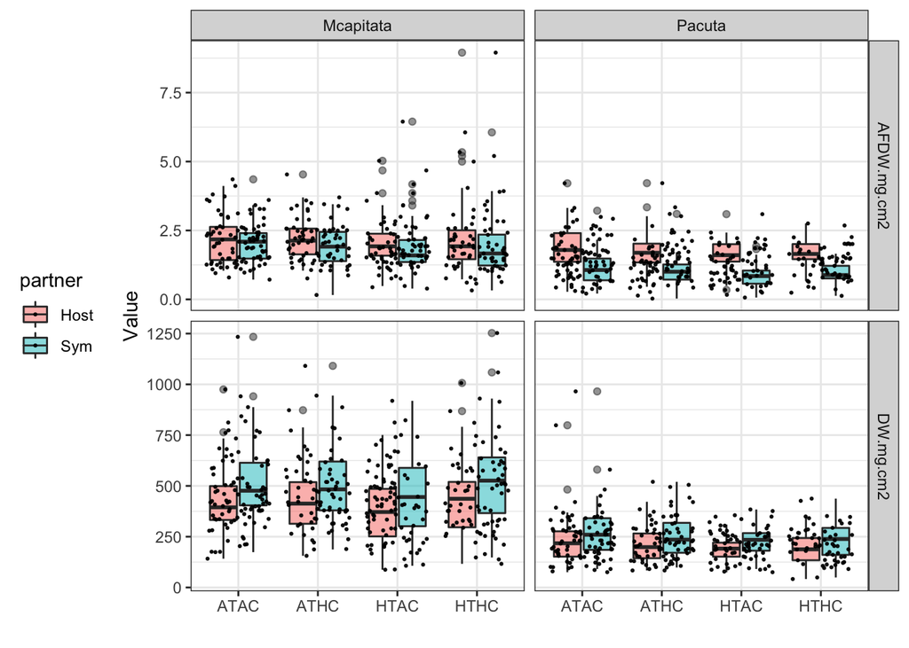

```r
cols <- c("lightblue", "blue", "salmon", "red3")

HostSym_plot <- ggplot(AFDW_long, aes(x=Treatment, y=Value, fill=partner)) + geom_boxplot(alpha=0.5) +
  geom_jitter(color="black", size=0.4, alpha=0.9) + xlab("") + theme_bw() +
  theme(legend.position = "left") +
  facet_grid(Measurement ~ Species, scales = "free")
HostSym_plot
```

```r
ggsave(file="Output/Tissue_Biomass_HostvSym.pdf", HostSym_plot, width = 11, height = 6, units = c("in"))
```

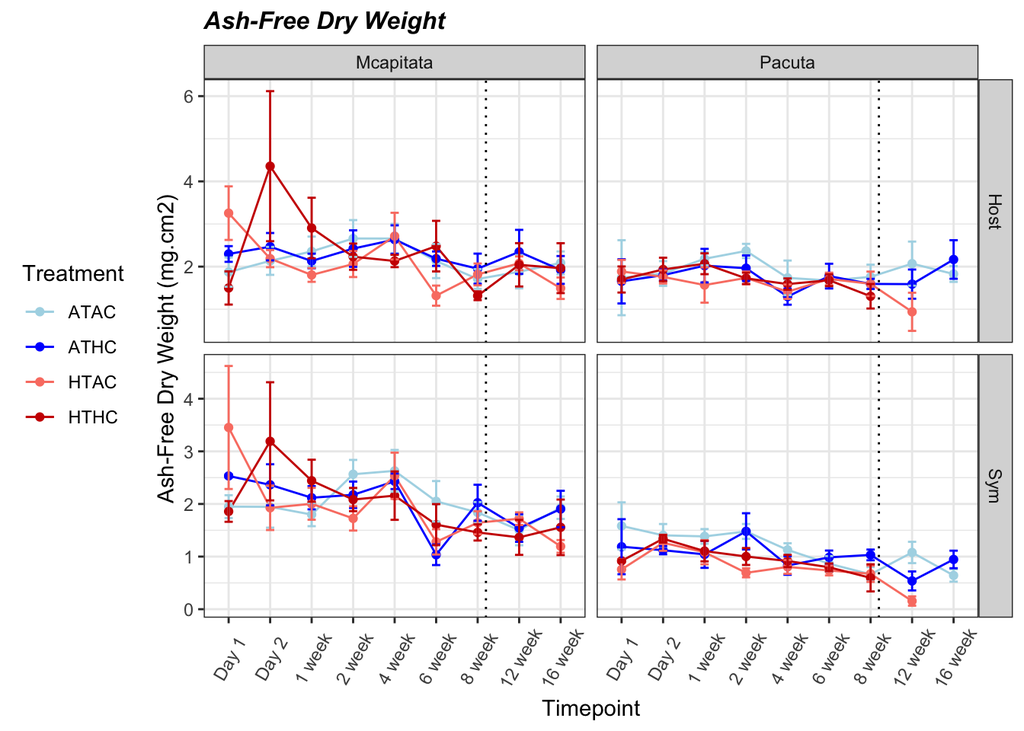

```r
AFDW_plot <- ggplot(AFDW_means, aes(x=Timepoint, y = Value, group = Treatment, color = Treatment)) +
  geom_line() + geom_point() +
  facet_grid(partner ~ Species, scales = "free") +
  geom_errorbar(aes(ymin=Value-se, ymax=Value+se), width=.2) +
  scale_color_manual(values = cols) +
  xlab("Timepoint") +
  ylab("Ash-Free Dry Weight (mg.cm2)") + # y-axis label and y axis range
  theme_bw() +
  ggtitle("Ash-Free Dry Weight") +
  theme(legend.position = "left") +
  geom_vline(xintercept = c(7.2), colour="black", linetype="dotted") +
  theme(plot.title = element_text(face = 'bold.italic', size = 12, hjust = 0)) +
  theme(axis.text.x = element_text(angle = 60, vjust = 0.5, hjust = 0.45)) #Set the text angle
AFDW_plot
```

```r
ggsave(file="Output/Final_Figures/Tissue_Biomass.pdf", AFDW_plot, width = 11, height = 6, units = c("in"))
```

AFDW things to address: 1. Mcap outlier in HTHC at Day 2 - 1197. But this occurs with both the Host and Sym fraction and similar pattern holds in respiration rates. 2. Won’t have AFDW values for 1327, 1174, or 1488. 3. 16 missing corals contribute to the wide ranges at 1, 2 days and 1 week. 4. 2863 - redo this point

Bleaching Fragment Test prior to running the rest of the samples.

This was a test batch of 12 samples to make sure we would get a signal from both healthy and bleached samples.

Reading in bleaching test information.

```r
Phys_testing <- read.csv("Physiology_variables/phys_testing.csv")
Phys_testing$Plug_ID <- as.character(Phys_testing$Plug_ID)
AFDW$Plug_ID <- as.character(AFDW$Plug_ID)

AFDW_testing <- full_join(AFDW, Phys_testing, by="Plug_ID") %>%
select(Plug_ID, partner, Species, Treatment, Timepoint, DW.mg.cm2, AFDW.mg.cm2, status, bleaching_score) %>% filter(!is.na(status))

AFDW_testing <- gather(AFDW_testing, "Measurement", "Value", 6:7) # changing columns to rows to allow for easier facet_grid in graphing section
```

Graphing bleach test data.

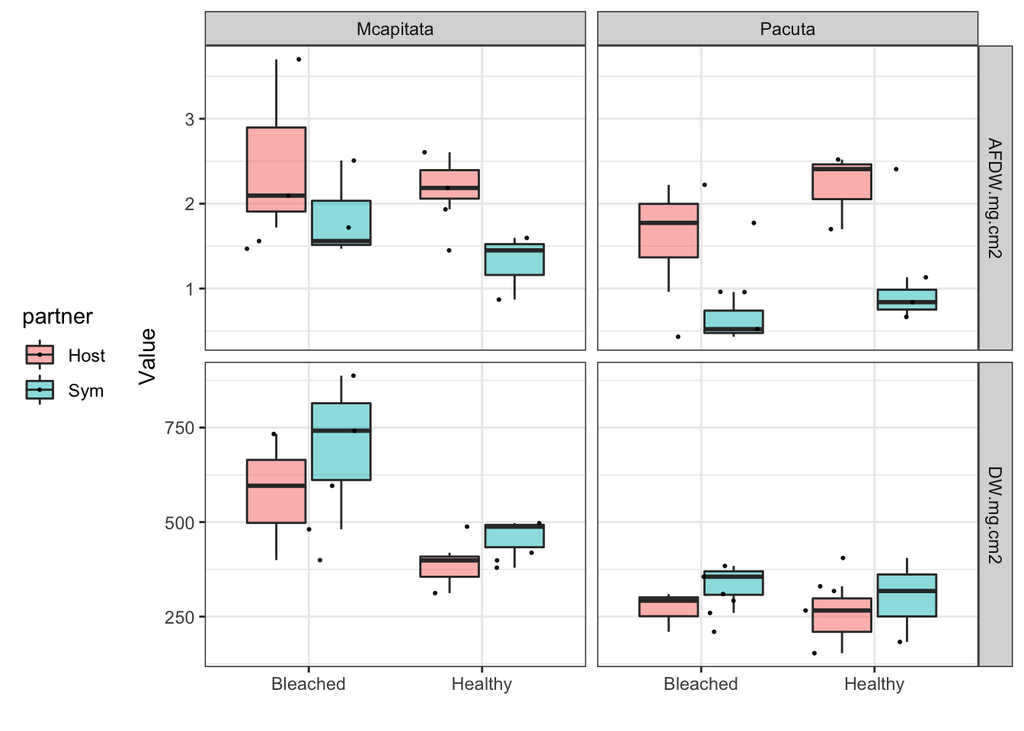

```r
Bleached1 <- ggplot(AFDW_testing, aes(x=status, y=Value, fill=partner)) + geom_boxplot(alpha=0.5) +
  geom_jitter(color="black", size=0.4, alpha=0.9) + xlab("") + theme_bw() +
  theme(legend.position = "left") +
  facet_grid(Measurement ~ Species, scales = "free")
Bleached1
```

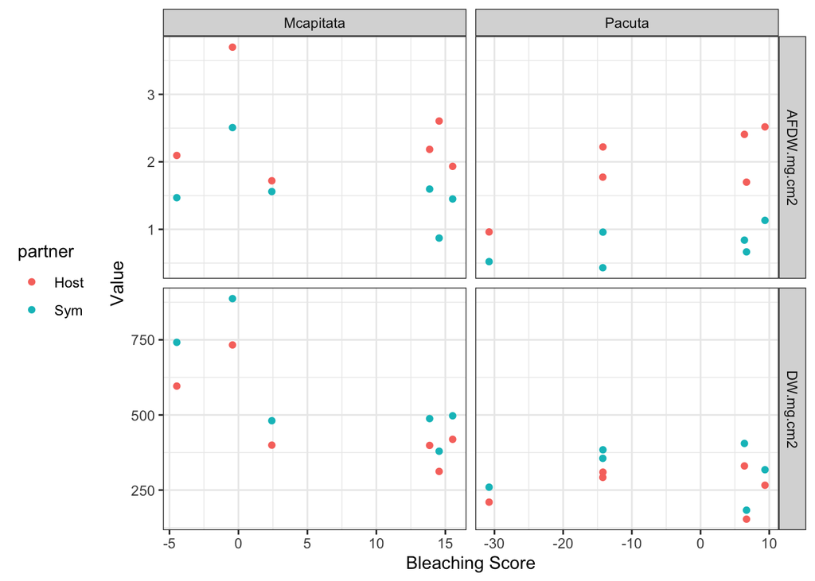

```r
Bleached2 <- ggplot(AFDW_testing, aes(x=bleaching_score, y=Value, color=partner)) + geom_point() +
  xlab("Bleaching Score") + theme_bw() +
  facet_grid(Measurement ~ Species, scales = "free") +
  theme(legend.position = "left")
Bleached2
```

```r
AFDW.Blch.Figs <- arrangeGrob(Bleached1, Bleached2, ncol=2)

ggsave(file="Output/Phystest_AFDW.pdf", AFDW.Blch.Figs, width = 15, height = 10, units = c("in"))
```